# Bifurcated Relationship between Amyloid and Tau Clearance

Julie Wisch

6/16/2021

When I started looking at longitudinal amyloid accumulation, I noticed a weird bifurcation in the relationship between pTau and AB42. When you look at the plot below (plotting all individuals in our ADRC dataset with 4 or more lumbar punctures), you can see around AB42 = 750 that there is a group of participants who have a very steep increase in pTau levels, and another group of participants who show a steady decrease in pTau levels.

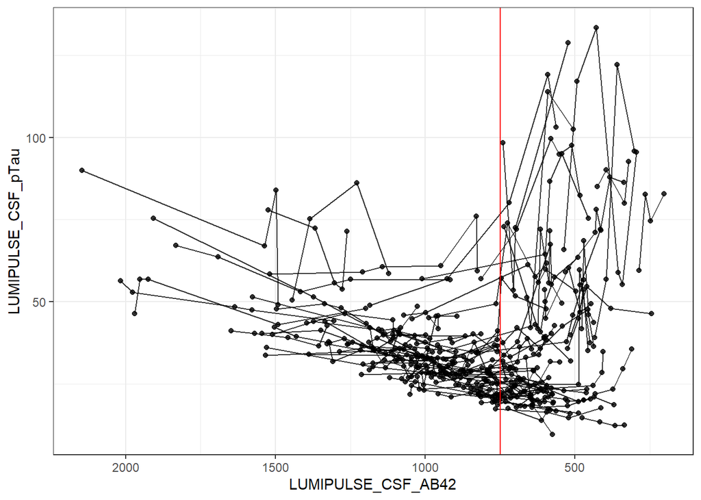

In order to separate participants based on these observed trajectories, I applied Growth Mixture Modeling (R Package lcmm). Growth Mixture Modeling takes into account repeated measures and allows the model to vary by both slope and intercept for each individual. Because all of our participants had completed at least 4 lumbar punctures, it felt reasonable to allow for varying slopes. While I judged by looking at the above figure that there were two distinct groups, I ran the growth mixture models on 1, 2, 3 and 4 latent classes to be sure that my personal judgment aligned with the optimized classification. The model formulation is shown below.

Instead of 2 classes, the growth mixture model identified 3 distinct latent clusters of individuals on the amyloid-tau trajectory. This was determined by finding the model that minimized BIC.

```
##        G    loglik npm      BIC   %class1  %class2   %class3  %class4
## gmm1_2 1 -1936.154   6 3900.401 100.00000
## gmm2_2 2 -1897.066  10 3840.954  36.11111 63.88889
## gmm3_2 3 -1884.637  14 3834.824  25.00000 11.11111 63.888889
## gmm4_2 4 -1879.565  18 3843.408  12.03704 63.88889  8.333333 15.74074
```

When we plot these individuals, we see that cluster 1 is somewhat transitional, cluster 2 is individuals with skyrocketing tau levels and low amyloid clearance, and cluster 3 is individuals with low amyloid clearance and low tau levels. Insel et al, 2017 (https://doi.org/10.3389/fnins.2017.00281) talk about “emerging AB pathology” as the time when individuals have early stage abnormal amyloid metabolism prior to meeting conventional preclinical AD criteria. We will use that terminology here.

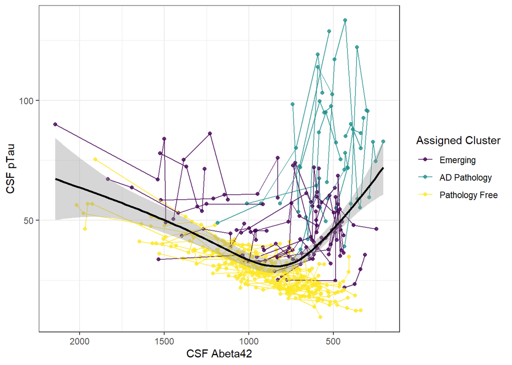

Above we show a single GAM fitted across all longitudinal visits. Below we show individual GAMs plotted for each cluster of participants.

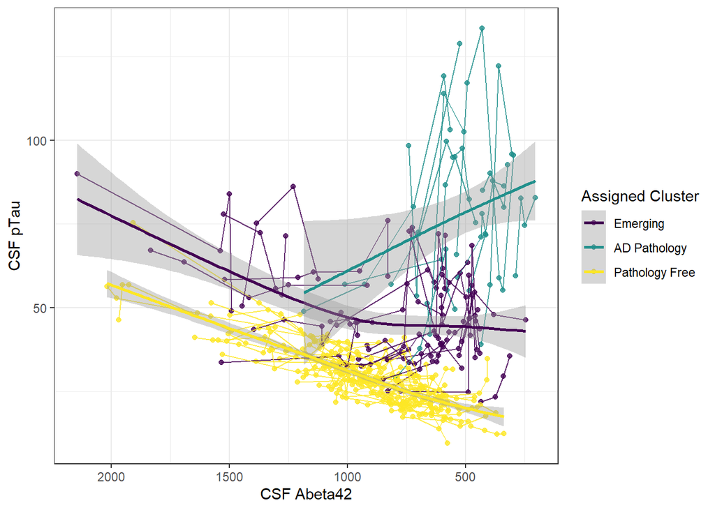

Here we extract the actual GAMMs for the three groups. I’m doing this so I can get the mean value for the Emerging Pathology guys once they are amyloid positive (CSF AB42 < 1098).

```
## [1] "Model forecasts for the AD cohort"
```

```
## [1] "Mean = 73.1629446008401"
```

```
## [1] "SE = 5.12990174346779"
```

```
## [1] "SD = 8.99818674284566"
```

```
## [1] "Model forecasts for the emerging cohort"
```

```
## [1] "Mean = 45.0358241500716"
```

```
## [1] "SE = 1.9397309556562"
```

```
## [1] "SD = 1.47221484421185"
```

```
## [1] "Model forecasts for the Pathology Free cohort"
```

```
## [1] "Mean = 24.6169297313964"
```

```
## [1] "SE = 0.59243871179783"
```

```
## [1] "SD = 4.84414079570308"
```

Now we will compare the trajectories of these individuals across the A-T-N-Cognition spectrum and see how they differ.

```
##                                 Stratified by upvoted_cluster_recent
##                                  Emerging       AD Pathology   Pathology Free
##   n                                 27             12             69
##   Age_at_LP_baseline (mean (SD)) 64.61 (6.01)   61.68 (7.59)   56.83 (7.56)
##   Age_at_LP_recent (mean (SD))   75.47 (5.95)   72.83 (6.52)   68.40 (7.56)
##   GENDER_baseline = 2 (%)           14 ( 51.9)      8 ( 66.7)     46 ( 66.7)
##   apoe_baseline (%)
##      23                              1 (  3.7)      0 (  0.0)      9 ( 13.2)
##      24                              2 (  7.4)      0 (  0.0)      2 (  2.9)
##      33                             12 ( 44.4)      5 ( 41.7)     45 ( 66.2)
##      34                             11 ( 40.7)      3 ( 25.0)     11 ( 16.2)
##      44                              1 (  3.7)      4 ( 33.3)      1 (  1.5)
##   race2_baseline (%)
##      2                               0 (  0.0)      0 (  0.0)      1 (  1.4)
##      4                               3 ( 11.1)      1 (  8.3)      5 (  7.2)
##      5                              24 ( 88.9)     11 ( 91.7)     63 ( 91.3)
##   EDUC_baseline (mean (SD))      16.22 (2.28)   14.75 (3.60)   16.14 (2.38)
##   cdr_baseline = 0 (%)              27 (100.0)     12 (100.0)     69 (100.0)
##   cdr_recent (%)
##      0                              25 ( 92.6)      7 ( 58.3)     68 ( 98.6)
##      0.5                             1 (  3.7)      4 ( 33.3)      1 (  1.4)
##      1                               1 (  3.7)      0 (  0.0)      0 (  0.0)
##      2                               0 (  0.0)      1 (  8.3)      0 (  0.0)
##   MMSE_baseline (mean (SD))      29.00 (1.27)   29.42 (1.08)   29.39 (0.88)
##   MMSE_recent (mean (SD))        28.89 (1.45)   27.75 (4.49)   29.35 (0.94)
##   sumbox_baseline (mean (SD))     0.02 (0.10)    0.00 (0.00)    0.01 (0.06)
##   sumbox_recent (mean (SD))       0.24 (0.99)    1.25 (2.84)    0.02 (0.13)
##                                 Stratified by upvoted_cluster_recent
##                                  p      test
##   n
##   Age_at_LP_baseline (mean (SD)) <0.001
##   Age_at_LP_recent (mean (SD))   <0.001
##   GENDER_baseline = 2 (%)         0.386
##   apoe_baseline (%)              <0.001
##      23
##      24
##      33
##      34
##      44
##   race2_baseline (%)              0.921
##      2
##      4
##      5
##   EDUC_baseline (mean (SD))       0.186
##   cdr_baseline = 0 (%)               NA
##   cdr_recent (%)                 <0.001
##      0
##      0.5
##      1
##      2
##   MMSE_baseline (mean (SD))       0.217
##   MMSE_recent (mean (SD))         0.017
##   sumbox_baseline (mean (SD))     0.678
##   sumbox_recent (mean (SD))       0.001
```

|  | Emerging | AD Pathology | Pathology Free | p | test |
| --- | --- | --- | --- | --- | --- |
| n | 27 | 12 | 69 |  |  |
| Age_at_LP_baseline (mean (SD)) | 64.61 (6.01) | 61.68 (7.59) | 56.83 (7.56) | <0.001 |  |
| Age_at_LP_recent (mean (SD)) | 75.47 (5.95) | 72.83 (6.52) | 68.40 (7.56) | <0.001 |  |
| GENDER_baseline = 2 (%) | 14 (51.9) | 8 (66.7) | 46 (66.7) | 0.386 |  |
| apoe_baseline (%) |  |  |  | <0.001 |  |
| 23 | 1 (3.7) | 0 (0.0) | 9 (13.2) |  |  |
| 24 | 2 (7.4) | 0 (0.0) | 2 (2.9) |  |  |
| 33 | 12 (44.4) | 5 (41.7) | 45 (66.2) |  |  |
| 34 | 11 (40.7) | 3 (25.0) | 11 (16.2) |  |  |
| 44 | 1 (3.7) | 4 (33.3) | 1 (1.5) |  |  |
| race2_baseline (%) |  |  |  | 0.921 |  |
| 2 | 0 (0.0) | 0 (0.0) | 1 (1.4) |  |  |
| 4 | 3 (11.1) | 1 (8.3) | 5 (7.2) |  |  |
| 5 | 24 (88.9) | 11 (91.7) | 63 (91.3) |  |  |
| EDUC_baseline (mean (SD)) | 16.22 (2.28) | 14.75 (3.60) | 16.14 (2.38) | 0.186 |  |
| cdr_baseline = 0 (%) | 27 (100.0) | 12 (100.0) | 69 (100.0) | NA |  |
| cdr_recent (%) |  |  |  | <0.001 |  |
| 0 | 25 (92.6) | 7 (58.3) | 68 (98.6) |  |  |
| 0.5 | 1 (3.7) | 4 (33.3) | 1 (1.4) |  |  |
| 1 | 1 (3.7) | 0 (0.0) | 0 (0.0) |  |  |
| 2 | 0 (0.0) | 1 (8.3) | 0 (0.0) |  |  |
| MMSE_baseline (mean (SD)) | 29.00 (1.27) | 29.42 (1.08) | 29.39 (0.88) | 0.217 |  |
| MMSE_recent (mean (SD)) | 28.89 (1.45) | 27.75 (4.49) | 29.35 (0.94) | 0.017 |  |
| sumbox_baseline (mean (SD)) | 0.02 (0.10) | 0.00 (0.00) | 0.01 (0.06) | 0.678 |  |
| sumbox_recent (mean (SD)) | 0.24 (0.99) | 1.25 (2.84) | 0.02 (0.13) | 0.001 |  |

### Individual trajectories vs Time

We expect AB42 to decline over time, so likely - given the orientation of the x axis in the figures above, timepoints are chronologically shown as you move from left to right for connected individuals. To validate this, we will plot the individual trajectories of participants with the most completed lumbar punctures in each of the three clusters. Our hypothesis is not exactly true, but it is generally true.

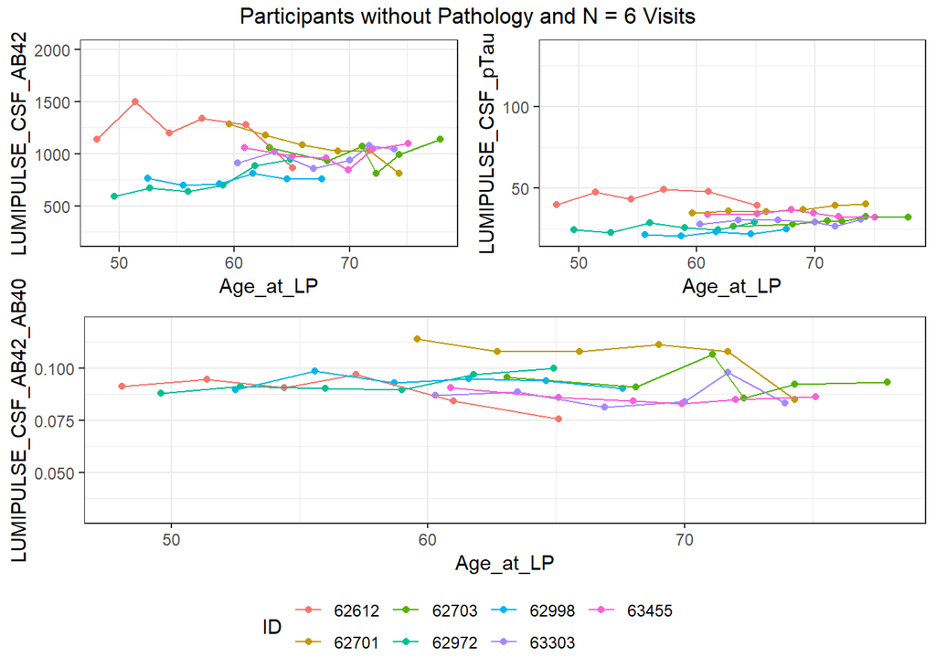

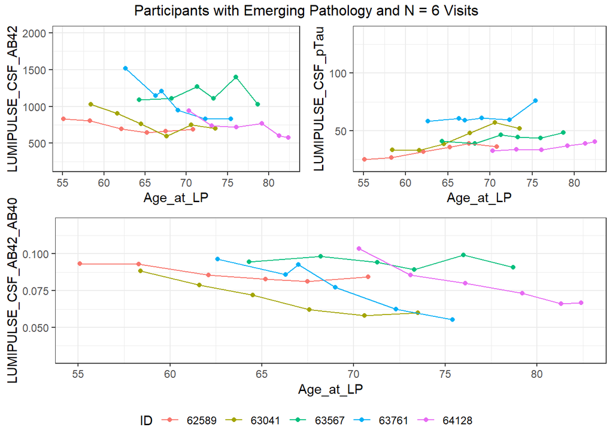

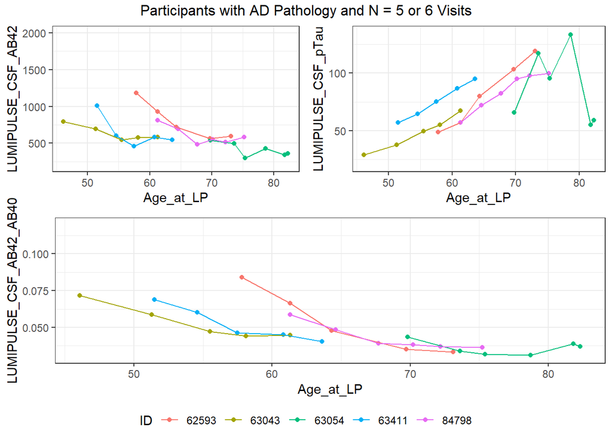

### Demographics

These are highly committed participants who have longitudinal measures for nearly every modality. We do not have much longitudinal PET Tau on these participants and thus in our summary table we only show a baseline tau pet value for each.

|  | Emerging (N=27) | AD Pathology (N=12) | Pathology Free (N=69) | Overall (N=108) |
| --- | --- | --- | --- | --- |
| Age_at_LP_baseline |  |  |  |  |
| Mean (SD) | 64.6 (6.01) | 61.7 (7.59) | 56.8 (7.56) | 59.3 (7.92) |
| Median [Min, Max] | 66.4 [49.2, 73.5] | 63.0 [46.1, 70.8] | 56.4 [43.6, 74.8] | 59.2 [43.6, 74.8] |
| Age_at_LP_recent |  |  |  |  |
| Mean (SD) | 75.5 (5.95) | 72.8 (6.52) | 68.4 (7.56) | 70.7 (7.68) |
| Median [Min, Max] | 76.6 [58.5, 84.0] | 74.1 [61.3, 82.3] | 67.5 [55.0, 86.9] | 70.9 [55.0, 86.9] |
| factor(GENDER_baseline) |  |  |  |  |
| 1 | 13.0 (48.1%) | 4.00 (33.3%) | 23.0 (33.3%) | 40.0 (37.0%) |
| 2 | 14.0 (51.9%) | 8.00 (66.7%) | 46.0 (66.7%) | 68.0 (63.0%) |
| factor(apoe_baseline) |  |  |  |  |
| 23 | 1.00 (3.7%) | 0 (0%) | 9.00 (13.0%) | 10.0 (9.3%) |
| 24 | 2.00 (7.4%) | 0 (0%) | 2.00 (2.9%) | 4.00 (3.7%) |
| 33 | 12.0 (44.4%) | 5.00 (41.7%) | 45.0 (65.2%) | 62.0 (57.4%) |
| 34 | 11.0 (40.7%) | 3.00 (25.0%) | 11.0 (15.9%) | 25.0 (23.1%) |
| 44 | 1.00 (3.7%) | 4.00 (33.3%) | 1.00 (1.4%) | 6.00 (5.6%) |
| Missing | 0 (0%) | 0 (0%) | 1.00 (1.4%) | 1.00 (0.9%) |
| factor(race2_baseline) |  |  |  |  |
| 2 | 0 (0%) | 0 (0%) | 1.00 (1.4%) | 1.00 (0.9%) |
| 4 | 3.00 (11.1%) | 1.00 (8.3%) | 5.00 (7.2%) | 9.00 (8.3%) |
| 5 | 24.0 (88.9%) | 11.0 (91.7%) | 63.0 (91.3%) | 98.0 (90.7%) |
| EDUC_baseline |  |  |  |  |
| Mean (SD) | 16.2 (2.28) | 14.8 (3.60) | 16.1 (2.38) | 16.0 (2.53) |
| Median [Min, Max] | 16.0 [12.0, 20.0] | 16.0 [6.00, 18.0] | 16.0 [12.0, 20.0] | 16.0 [6.00, 20.0] |
| LUMIPULSE_CSF_AB42_baseline |  |  |  |  |
| Mean (SD) | 930 (339) | 655 (261) | 912 (259) | 888 (291) |
| Median [Min, Max] | 910 [433, 1530] | 593 [287, 1180] | 908 [366, 1650] | 871 [287, 1650] |
| LUMIPULSE_CSF_AB42_recent |  |  |  |  |
| Mean (SD) | 773 (376) | 474 (150) | 956 (347) | 857 (371) |
| Median [Min, Max] | 658 [311, 1830] | 487 [249, 741] | 922 [406, 2020] | 799 [249, 2020] |
| LUMIPULSE_CSF_AB40_baseline |  |  |  |  |

[output cut: 94 more lines]

### Amyloid

Accepted CSF cutoffs for PET equivalency are shown as relevant

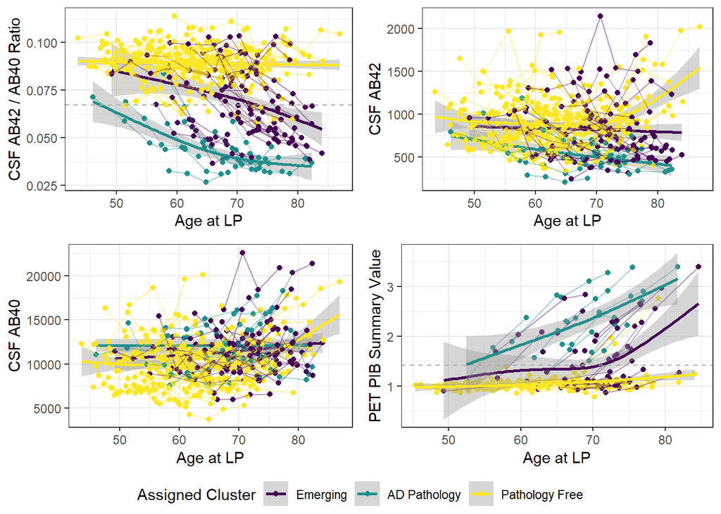

### Tau

Accepted CSF cutoffs for PET equivalency are shown as relevant

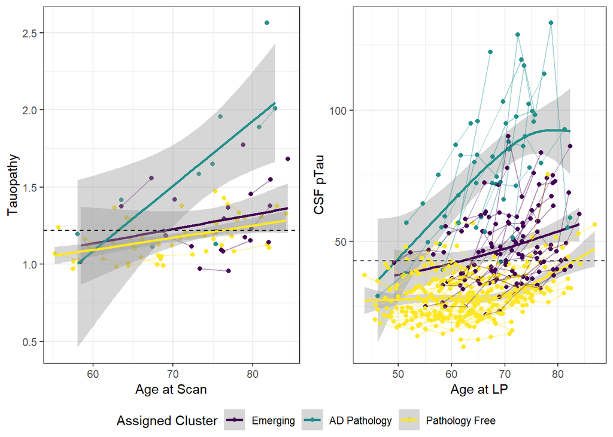

### Neurodegeneration

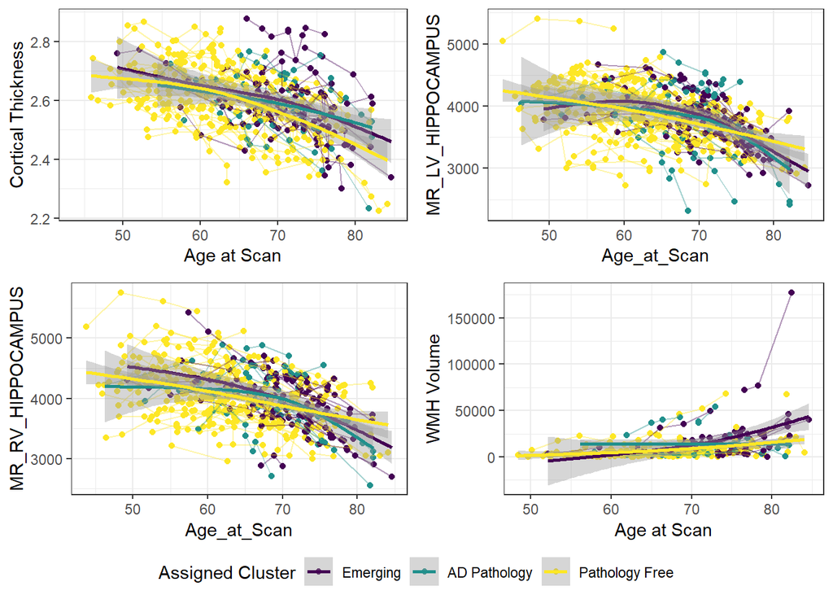

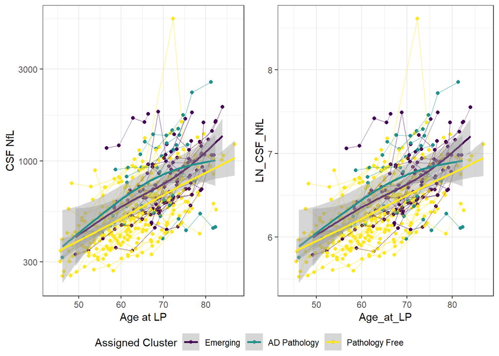

### Survival Analysis

We are able to complete a survival analysis on time to Amyloid Positivity (as measured by CSF AB42/AB40 ratio) and time to Tau Positivity (as measured by CSF pTau). When we do this, we omit the participants that are already amyloid positive (13 / 108) or tau positive (20 / 108) before study enrollment. We consider the age at pathology positivity to be the first CSF appointment with a value surpassing either CSF AB42/40 < 0.0673 or CSF pTau > 42.5. When we do this we see statistically significant differences across the three strata for both Amyloid and Tau. These differences are what we would expect.

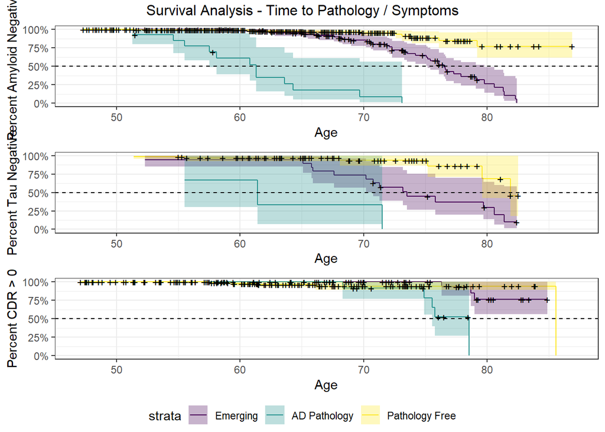

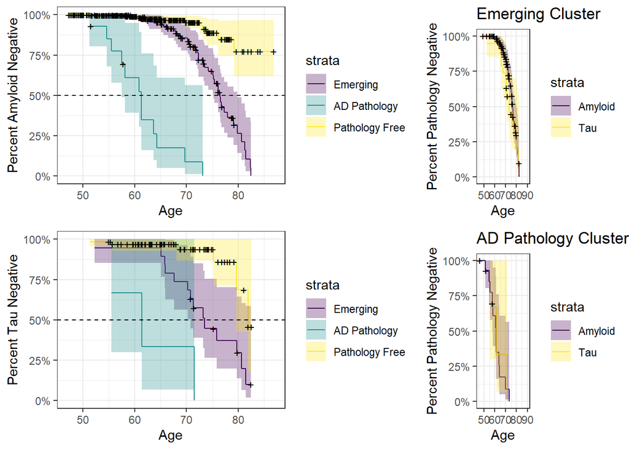

Of note - this is not the best way to talk about proteomics. Pelora generates lists of clusters working in tandem. I’m really not sure how to think about them - we need to consult with Carlos. Further, because I used cross-validation (which I think is appropriate given the N), how do we balance each independent model output? I need advice.

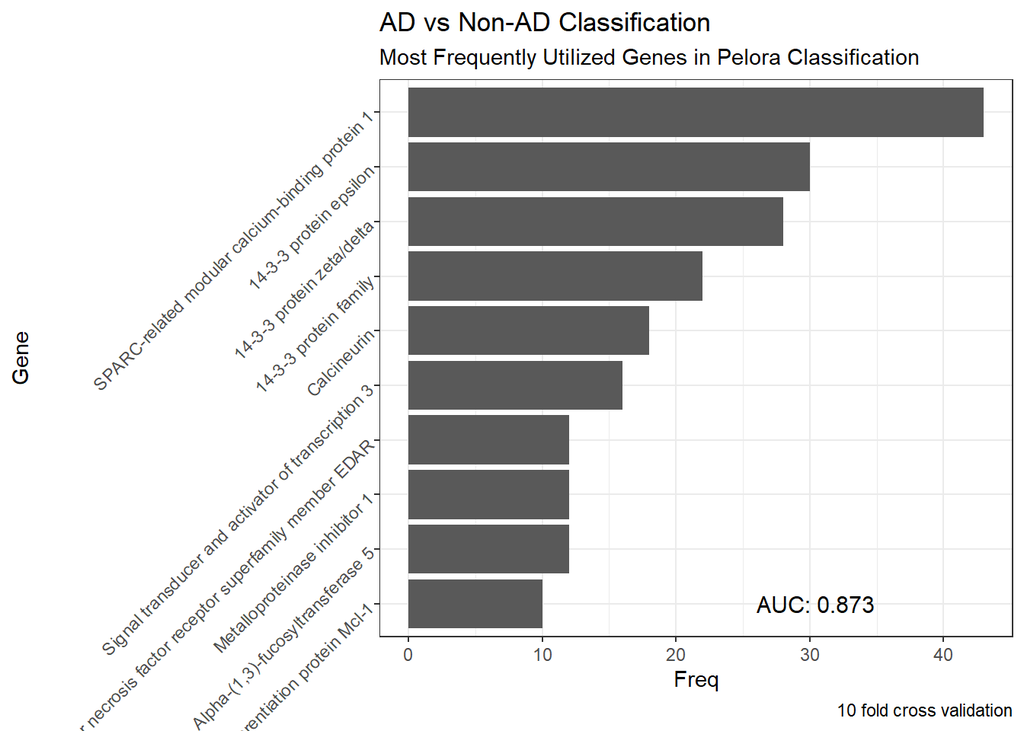

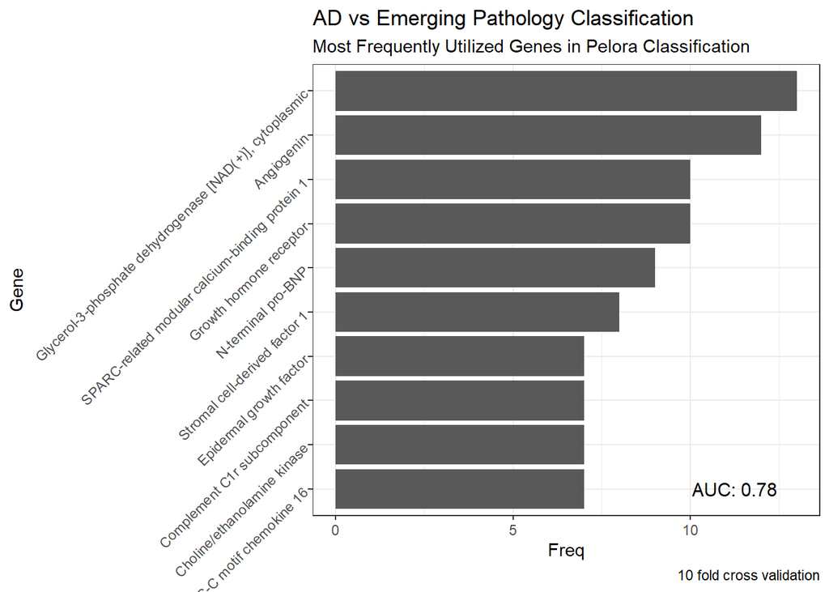

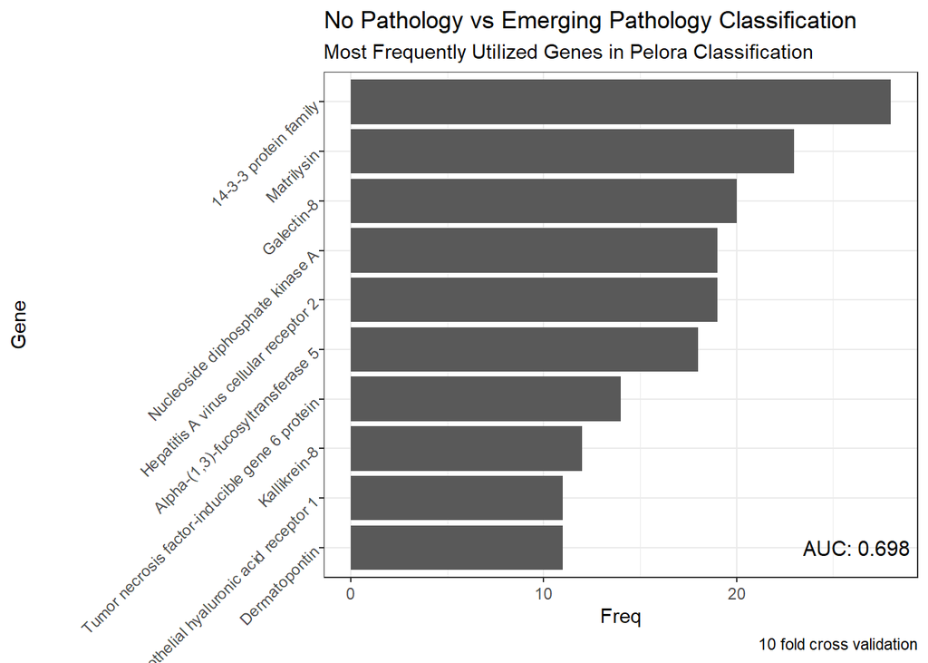

I’m thinking that using cross-validation helps confirm for us that there is reasonable robustness to the model, but when we want to actually make inferences for this cohort, we should train on the entire dataset and examine those gene clusters.

#### AD vs Non-AD

When we train and test on the same dataset, we do better than the cross-validated number, which is to be expected.

[output not shown]

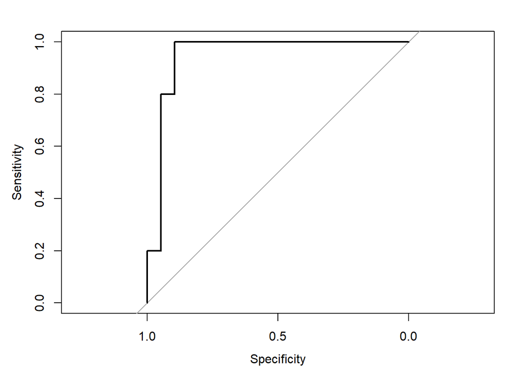

```
## Area under the curve: 0.9474
```

```
## [1] "First Cluster of Proteomics used for classification:"
```

```
##  [1] "Bone morphogenetic protein receptor type-2"
##  [2] "Interleukin-1 Receptor accessory protein"
##  [3] "Aggrecan core protein"
##  [4] "Polymeric immunoglobulin receptor"
##  [5] "Hepatocyte growth factor receptor"
##  [6] "Sialic acid-binding Ig-like lectin 7"
##  [7] "40S ribosomal protein SA"
##  [8] "Glycerol-3-phosphate dehydrogenase [NAD(+)], cytoplasmic"
##  [9] "Protein S100-A4"
## [10] "Leptin"
## [11] "Decorin"
## [12] "Fibronectin"
## [13] "Calcium/calmodulin-dependent 3',5'-cyclic nucleotide phosphodiesterase 1A"
## [14] "Eotaxin"
## [15] "Tyrosine-protein kinase transmembrane receptor ROR1"
## [16] "Peptidyl-prolyl cis-trans isomerase F, mitochondrial"
```

```
## [1] "Second Cluster of Proteomics used for classification:"
```

```
## [1] "Tyrosine-protein kinase receptor TYRO3"
## [2] "Neuroblastoma suppressor of tumorigenicity 1"
## [3] "Prolactin"
## [4] "Interleukin-17 receptor B"
## [5] "Leucine-rich repeat transmembrane protein FLRT1"
## [6] "Cerebral dopamine neurotrophic factor"
## [7] "Kallikrein-8"
## [8] "Sonic hedgehog protein"
## [9] "Apolipoprotein M"
```

```
## [1] "First Cluster of Proteomics used for classification:"
```

```
##  [1] "Bone morphogenetic protein receptor type-2"
##  [2] "Interleukin-1 Receptor accessory protein"
##  [3] "Aggrecan core protein"
##  [4] "Polymeric immunoglobulin receptor"
##  [5] "Hepatocyte growth factor receptor"
##  [6] "Sialic acid-binding Ig-like lectin 7"
##  [7] "40S ribosomal protein SA"
##  [8] "Glycerol-3-phosphate dehydrogenase [NAD(+)], cytoplasmic"
##  [9] "Protein S100-A4"
## [10] "Leptin"
## [11] "Decorin"
## [12] "Fibronectin"
## [13] "Calcium/calmodulin-dependent 3',5'-cyclic nucleotide phosphodiesterase 1A"
## [14] "Eotaxin"
## [15] "Tyrosine-protein kinase transmembrane receptor ROR1"
## [16] "Peptidyl-prolyl cis-trans isomerase F, mitochondrial"
```

```
## [1] "Second Cluster of Proteomics used for classification:"
```

```
## [1] "Tyrosine-protein kinase receptor TYRO3"
## [2] "Neuroblastoma suppressor of tumorigenicity 1"
## [3] "Prolactin"
## [4] "Interleukin-17 receptor B"
## [5] "Leucine-rich repeat transmembrane protein FLRT1"
## [6] "Cerebral dopamine neurotrophic factor"
## [7] "Kallikrein-8"
## [8] "Sonic hedgehog protein"
## [9] "Apolipoprotein M"
```

```
## [1] "Third Cluster of Proteomics used for classification:"
```

```
##  [1] "Tumor necrosis factor receptor superfamily member 4"
##  [2] "Neuroblastoma suppressor of tumorigenicity 1"
##  [3] "Cysteine-rich with EGF-like domain protein 1"
##  [4] "Leptin receptor"
##  [5] "L-Selectin"
##  [6] "Leucine-rich repeat transmembrane protein FLRT1"
##  [7] "Amphoterin-induced protein 2"
##  [8] "Protein jagged-1"
##  [9] "Tyrosine-protein kinase receptor TYRO3"
## [10] "Calcium/calmodulin-dependent 3',5'-cyclic nucleotide phosphodiesterase 1A"
## [11] "Cytochrome P450 3A4"
## [12] "Interleukin-17 receptor B"
## [13] "SUMO-conjugating enzyme UBC9"
```

#### Emerging Pathology vs No Pathology

#### Further Analysis of Proteins of Interest

Calcineurin makes up about 1% of total neural proteins. It is involved in neuronal plasticity and has been shown to be hyper-active within AD (Reese & Taglialatela, 2011).

SPARC enhances Blood Brain Barrier permeability, promotes neuroinflammation, and prolongs pro-inflammatory M1 phase of microglia (Pilozzi et al, 2020).

The family of 14-3-3 proteins are scaffolding proteins that interact with tau and regulate tau phosphorylation and aggregation (Chen et al, 2019)

Angiogen is most commonly associated with Parksinsons and ALS, but a mutation in Angiogen has also been found in association with AD (Stella et al, 2019). It is expressed and enriched in motor neurons, and accumulates under conditions of cellular stress like oxidative stress (Prehn & Jirstrom, 2020).

Inhibition of galectin-8 increases seeded tau aggregation.

Glycerol-3-phosphate dehydrogenase [NAD(+)], cytoplasmic was originally identified as involved in aerobic metabolism of glucose. It has been found to associate with APP and is significantly inhibited in the progression of AD due to oxidative modification (Butterfield et al, 2010).

### Cognition

lmdelay seems to be a very sensitive cognitive test

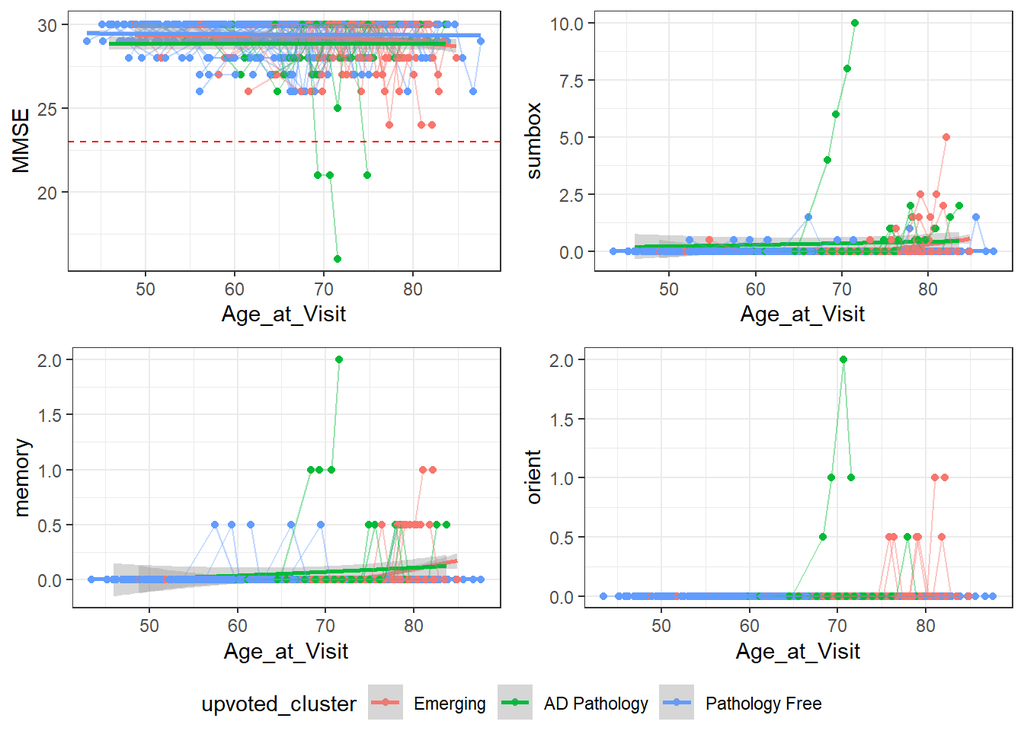

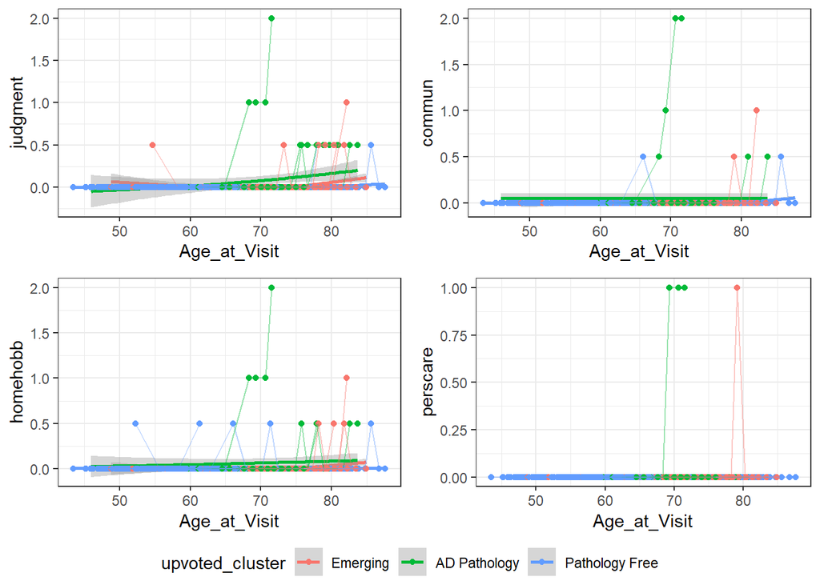

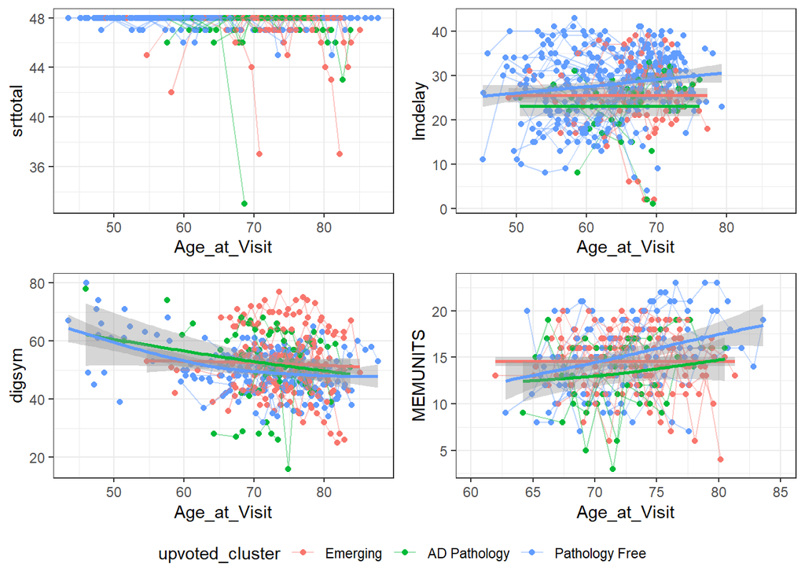

#### Plots for drafted manuscript

|  | Emerging (N=27) | AD Pathology (N=12) | Pathology Free (N=69) | Overall (N=108) |
| --- | --- | --- | --- | --- |
| Age_at_LP_baseline |  |  |  |  |
| Mean (SD) | 64.6 (6.01) | 61.7 (7.59) | 56.8 (7.56) | 59.3 (7.92) |
| Median [Min, Max] | 66.4 [49.2, 73.5] | 63.0 [46.1, 70.8] | 56.4 [43.6, 74.8] | 59.2 [43.6, 74.8] |
| Age_at_LP_recent |  |  |  |  |
| Mean (SD) | 75.5 (5.95) | 72.8 (6.52) | 68.4 (7.56) | 70.7 (7.68) |
| Median [Min, Max] | 76.6 [58.5, 84.0] | 74.1 [61.3, 82.3] | 67.5 [55.0, 86.9] | 70.9 [55.0, 86.9] |
| factor(GENDER_baseline) |  |  |  |  |
| 1 | 13.0 (48.1%) | 4.00 (33.3%) | 23.0 (33.3%) | 40.0 (37.0%) |
| 2 | 14.0 (51.9%) | 8.00 (66.7%) | 46.0 (66.7%) | 68.0 (63.0%) |
| factor(apoe_baseline) |  |  |  |  |
| 23 | 1.00 (3.7%) | 0 (0%) | 9.00 (13.0%) | 10.0 (9.3%) |
| 24 | 2.00 (7.4%) | 0 (0%) | 2.00 (2.9%) | 4.00 (3.7%) |
| 33 | 12.0 (44.4%) | 5.00 (41.7%) | 45.0 (65.2%) | 62.0 (57.4%) |
| 34 | 11.0 (40.7%) | 3.00 (25.0%) | 11.0 (15.9%) | 25.0 (23.1%) |
| 44 | 1.00 (3.7%) | 4.00 (33.3%) | 1.00 (1.4%) | 6.00 (5.6%) |
| Missing | 0 (0%) | 0 (0%) | 1.00 (1.4%) | 1.00 (0.9%) |
| factor(race2_baseline) |  |  |  |  |
| 2 | 0 (0%) | 0 (0%) | 1.00 (1.4%) | 1.00 (0.9%) |
| 4 | 3.00 (11.1%) | 1.00 (8.3%) | 5.00 (7.2%) | 9.00 (8.3%) |
| 5 | 24.0 (88.9%) | 11.0 (91.7%) | 63.0 (91.3%) | 98.0 (90.7%) |
| EDUC_baseline |  |  |  |  |
| Mean (SD) | 16.2 (2.28) | 14.8 (3.60) | 16.1 (2.38) | 16.0 (2.53) |
| Median [Min, Max] | 16.0 [12.0, 20.0] | 16.0 [6.00, 18.0] | 16.0 [12.0, 20.0] | 16.0 [6.00, 20.0] |
| LUMIPULSE_CSF_AB42_baseline |  |  |  |  |
| Mean (SD) | 930 (339) | 655 (261) | 912 (259) | 888 (291) |
| Median [Min, Max] | 910 [433, 1530] | 593 [287, 1180] | 908 [366, 1650] | 871 [287, 1650] |
| LUMIPULSE_CSF_AB42_recent |  |  |  |  |
| Mean (SD) | 773 (376) | 474 (150) | 956 (347) | 857 (371) |
| Median [Min, Max] | 658 [311, 1830] | 487 [249, 741] | 922 [406, 2020] | 799 [249, 2020] |
| LUMIPULSE_CSF_AB42_AB40_baseline |  |  |  |  |

[output cut: 66 more lines]

|  | Emerging (N=27) | AD Pathology (N=12) | Pathology Free (N=69) | Overall (N=108) |
| --- | --- | --- | --- | --- |
| Age_at_LP_baseline |  |  |  |  |
| Mean (SD) | 64.6 (6.01) | 61.7 (7.59) | 56.8 (7.56) | 59.3 (7.92) |
| Median [Min, Max] | 66.4 [49.2, 73.5] | 63.0 [46.1, 70.8] | 56.4 [43.6, 74.8] | 59.2 [43.6, 74.8] |
| Age_at_LP_recent |  |  |  |  |
| Mean (SD) | 75.5 (5.95) | 72.8 (6.52) | 68.4 (7.56) | 70.7 (7.68) |
| Median [Min, Max] | 76.6 [58.5, 84.0] | 74.1 [61.3, 82.3] | 67.5 [55.0, 86.9] | 70.9 [55.0, 86.9] |
| factor(GENDER_baseline) |  |  |  |  |
| 1 | 13.0 (48.1%) | 4.00 (33.3%) | 23.0 (33.3%) | 40.0 (37.0%) |
| 2 | 14.0 (51.9%) | 8.00 (66.7%) | 46.0 (66.7%) | 68.0 (63.0%) |
| factor(apoe_baseline) |  |  |  |  |
| 23 | 1.00 (3.7%) | 0 (0%) | 9.00 (13.0%) | 10.0 (9.3%) |
| 24 | 2.00 (7.4%) | 0 (0%) | 2.00 (2.9%) | 4.00 (3.7%) |
| 33 | 12.0 (44.4%) | 5.00 (41.7%) | 45.0 (65.2%) | 62.0 (57.4%) |
| 34 | 11.0 (40.7%) | 3.00 (25.0%) | 11.0 (15.9%) | 25.0 (23.1%) |
| 44 | 1.00 (3.7%) | 4.00 (33.3%) | 1.00 (1.4%) | 6.00 (5.6%) |
| Missing | 0 (0%) | 0 (0%) | 1.00 (1.4%) | 1.00 (0.9%) |
| factor(race2_baseline) |  |  |  |  |
| 2 | 0 (0%) | 0 (0%) | 1.00 (1.4%) | 1.00 (0.9%) |
| 4 | 3.00 (11.1%) | 1.00 (8.3%) | 5.00 (7.2%) | 9.00 (8.3%) |
| 5 | 24.0 (88.9%) | 11.0 (91.7%) | 63.0 (91.3%) | 98.0 (90.7%) |
| EDUC_baseline |  |  |  |  |
| Mean (SD) | 16.2 (2.28) | 14.8 (3.60) | 16.1 (2.38) | 16.0 (2.53) |
| Median [Min, Max] | 16.0 [12.0, 20.0] | 16.0 [6.00, 18.0] | 16.0 [12.0, 20.0] | 16.0 [6.00, 20.0] |
| LUMIPULSE_CSF_AB42_baseline |  |  |  |  |
| Mean (SD) | 930 (339) | 655 (261) | 912 (259) | 888 (291) |
| Median [Min, Max] | 910 [433, 1530] | 593 [287, 1180] | 908 [366, 1650] | 871 [287, 1650] |
| LUMIPULSE_CSF_AB42_recent |  |  |  |  |
| Mean (SD) | 773 (376) | 474 (150) | 956 (347) | 857 (371) |
| Median [Min, Max] | 658 [311, 1830] | 487 [249, 741] | 922 [406, 2020] | 799 [249, 2020] |
| LUMIPULSE_CSF_AB42_AB40_baseline |  |  |  |  |

[output cut: 66 more lines]

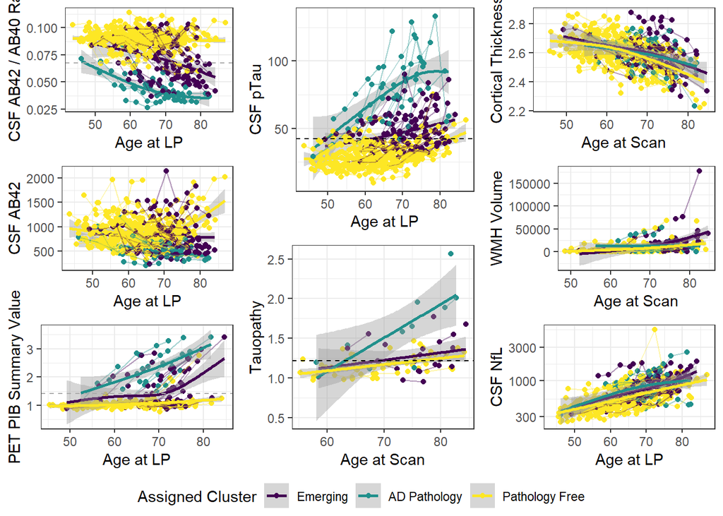

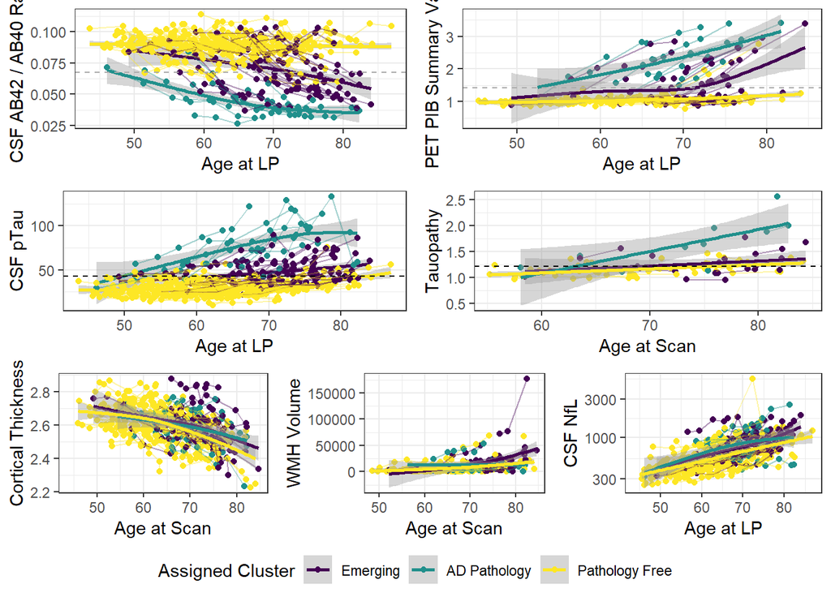